# Data Analysis Example: Student Height

Code Example – Lecture 02

Claus Aranha

# Introduction

This example analyses a survey from two classes of students about their height and weight. What can we learn about these students from this data?

# Data

The data for this example was obtained from Felipe Campelo’s “Analysis and Design of Experiments” course. and is available as a .csv file in the “rawdata” subdirectory.

```r
students <- read.csv("rawdata/student_data.csv")
students # this is an R dataframe
```

```
##    ID Course Gender Height.m Weight.kg
## 1   1  PPGEE      F     1.57      45.5
## 2   2  PPGEE      F     1.62      53.0
## 3   3  PPGEE      F     1.70      57.0
## 4   4  PPGEE      F     1.62      59.0
## 5   5  PPGEE      F     1.67      63.0
## 6   6  PPGEE      F     1.76      78.0
## 7   7  PPGEE      F     1.64      51.0
## 8   8  PPGEE      M     1.79      80.0
## 9   9  PPGEE      M     1.58      58.0
## 10 10  PPGEE      M     1.74      85.0
## 11 11  PPGEE      M     1.75     115.0
## 12 12  PPGEE      M     1.78      71.0
## 13 13  PPGEE      M     1.71      71.0
## 14 14  PPGEE      M     1.78      86.0
```

[output cut: 35 more lines]

> **Note:** When doing data analysis, it is always good to keep your raw (original) data files in a separate directory. Data analysis usually requires modifications to the data frame, so it is important to have the original, non-modified data somewhere handy.

# Simple Analysis and visualization:

What is the mean height and weight of these students?

```r
mean.height <- mean(students$Height.m)   # Student mean height
mean.weight <- mean(students$Weight.kg)   # Student mean weight

print(c(mean.height, mean.weight))
```

```
## [1]  1.740204 72.546939
```

We are interested in the BMI (Body Mass Index) of the students. The BMI is sometimes used to indicate the relationship between the height and the weight of a student, and is given by the formula:

$BMI = \frac{Weight}{Height^2}$

Let’s calculate the BMI and add it to our `students` dataframe.

```r
  bmi = students$Weight.kg / (students$Height.m ** 2)
  students["BMI"] <- bmi
  students
```

```
##    ID Course Gender Height.m Weight.kg      BMI
## 1   1  PPGEE      F     1.57      45.5 18.45917
## 2   2  PPGEE      F     1.62      53.0 20.19509
## 3   3  PPGEE      F     1.70      57.0 19.72318
## 4   4  PPGEE      F     1.62      59.0 22.48133
## 5   5  PPGEE      F     1.67      63.0 22.58955
## 6   6  PPGEE      F     1.76      78.0 25.18079
## 7   7  PPGEE      F     1.64      51.0 18.96193
## 8   8  PPGEE      M     1.79      80.0 24.96801
## 9   9  PPGEE      M     1.58      58.0 23.23346
## 10 10  PPGEE      M     1.74      85.0 28.07504
## 11 11  PPGEE      M     1.75     115.0 37.55102
## 12 12  PPGEE      M     1.78      71.0 22.40879
## 13 13  PPGEE      M     1.71      71.0 24.28098
## 14 14  PPGEE      M     1.78      86.0 27.14304
```

[output cut: 35 more lines]

The mean BMI of all the students is 23.7461942 with an estimated error of 4.1796013.

# Figures and confidence interval:

When analyzing data, it is important to accompany point indicators (values) with statistical intervals. Using **figures** also gives the reader a good intuition of the relationship between all the values under study.

Let’s understand the BMI of the students in this class a little bit more, by plotting the 95% confidence interval for this estimator:

Let’s plot the mean BMI of the students, as well as the 95% confidence interval for this estimator:

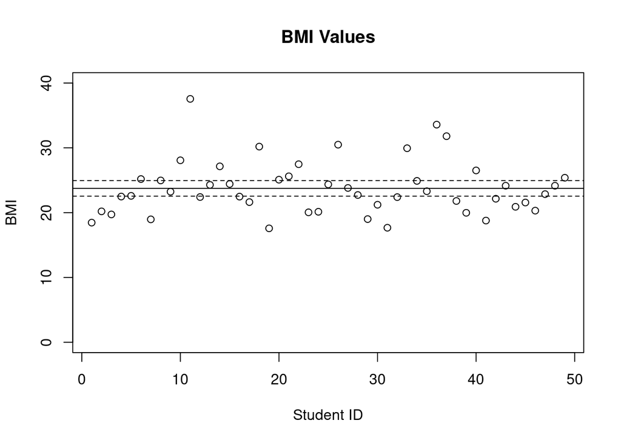

```r
values <- students$BMI  # shorter name for variable
ci_alpha <- 0.05        # Alpha value for confidence interval. Confidence = 1 - alpha.
# calculating low and high bounds for ci
ci_low <- mean(values) + qt(ci_alpha/2, length(values)-1) * (sd(values)/sqrt(length(values)))
ci_hi <- mean(values) + qt(1 - ci_alpha/2, length(values)-1) * (sd(values)/sqrt(length(values)))

# plot the values and the confidence interval of the mean
plot(students$BMI, ylim = c(0,40), xlab = "Student ID", ylab = "BMI") # plot all the values
title("BMI Values")
abline(h = mean(students$BMI)) # plot a line for the sample mean
abline(h = ci_low, lty=2) # plot a line for the lower CI bound
abline(h = ci_hi, lty=2) # plot a line for the upper CI bound
```

*TODO*: Print a prettier plot with ggplot.

# Investigating relationship between variables

Is there a difference in BMI between male and female students in this class?

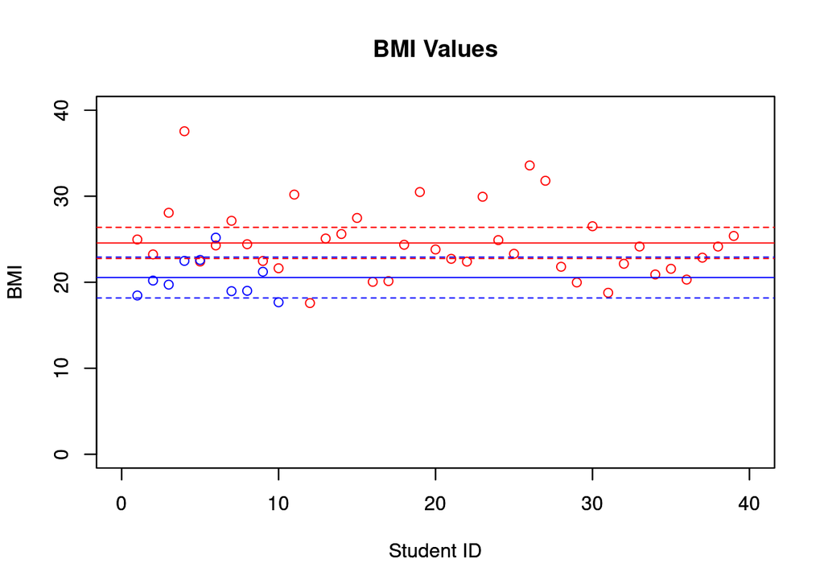

The plot above shows that not only the mean BMI of the female students (blue line) is lower, but the 95% confidence interval of the two measures has very little overlap.

But what does the confidence interval means in this scenario? Since we have information about all the students in our class, the confidence interval does not tells us much, unless we are assuming that this class is a representative sample of a larger population.

But at least now we know how to calculate a confidence interval!

# Other ways to observe data.

The histogram allows us to visualize some data by breaking it down into categories:

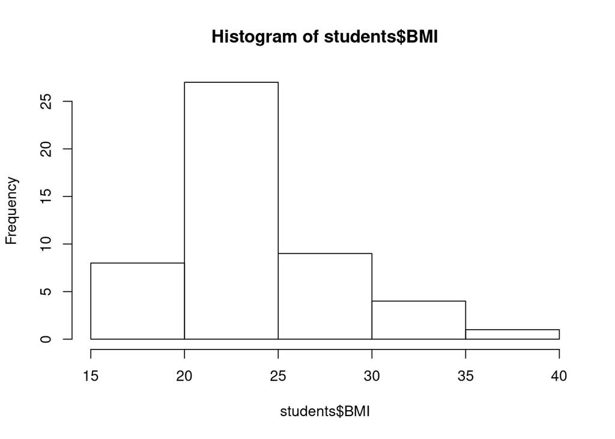

The boxplot gives us a good idea of the upper and lower limits in a sample, as well as the position of the majorities of the values in the sample.

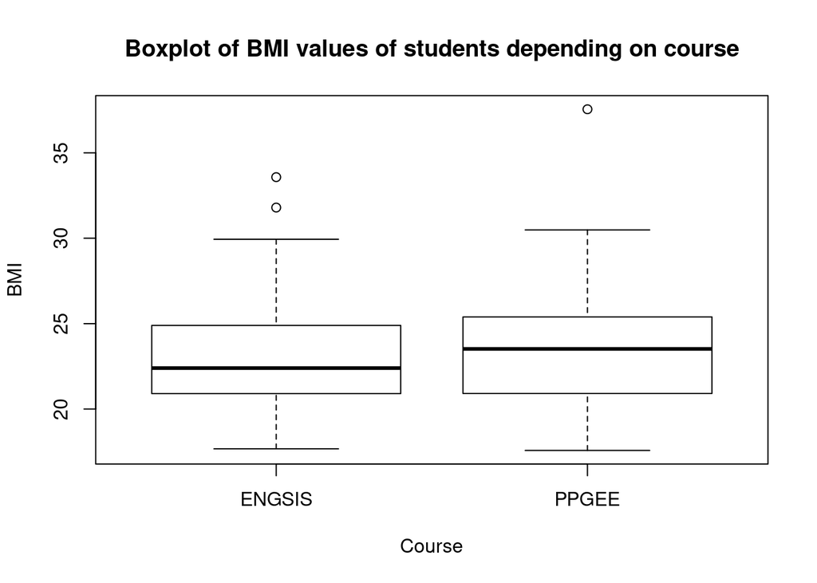